# Data Visulization with pdxTrees

`pdxTrees` is a data package composed of information on inventoried trees in Portland, OR. There are two datasets that can be accessed with this package:

- `get_pdxTrees_parks(version = "2019")` pulls in data on up to 25,534 trees from 174 Portland parks.
- `get_pdxTrees_parks(version = "2026")` pulls in data on up to 25,734 trees from 316 Portland parks.
- `get_pdxTrees_streets(version = "2019")` pulls in data on up to 218,602 trees located on Portland’s streets. A street tree is loosely defined as a tree generally in the public right-of-way, usually between the sidewalk and the street. *`get_pdxTrees_streets(version = "2026)` pulls in data on up to 252,180 trees located on Portland’s streets. A street tree is loosely defined as a tree generally in the public right-of-way, usually between the sidewalk and the street.

The street trees are categorized by one of the 95 Portland neighborhoods and the park trees are categorized by the public parks in which they grow.

Here are some examples of the different ways `pdxTrees` can be used in an educational setting to learn data visualization!

```r
# First make sure you have the package downloaded!

devtools::install_github("mcconvil/pdxTrees")

# Loading the required libraries

library(pdxTrees)
library(dplyr)
library(forcats)
library(devtools)
library(tidyverse)
```

## Load data into environment using a package function

```r
PDX_parks <- get_pdxTrees_parks()
```

# Create a histogram to explore Portland park tree heights

The following: *Uses the data that was loaded using a package function* Makes a colored histogram to display tree heights *Makes 30 bins for data

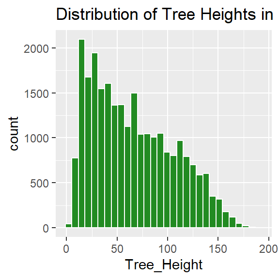

```r
ggplot(data = PDX_parks,
 mapping = aes(x = Tree_Height)) +
 geom_histogram(color = "white",
 fill = "forestgreen",
 bins = 30) +
  labs(title = "Distribution of Tree Heights in Portland Parks")
```

# Create a bar graph comparing native and nonnative trees in Portland Parks

This bar graph compares native tree species count to nonnative tree species count in Portland parks.

The following: *Removes NA values in the data that counts native and nonnative trees* Makes a bar graph comparing native and nonnative tree counts *Uses a color palette to differentiate

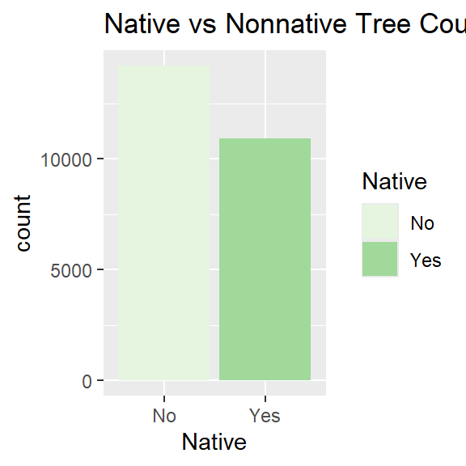

```r
native_parktrees <- PDX_parks %>%
  drop_na(Native)

ggplot(data = native_parktrees,
 mapping = aes(x = Native, fill = Native)) +
 geom_bar() +
  scale_fill_brewer(palette = "Greens") +
  labs( title = "Native vs Nonnative Tree Count in Portland Parks")
```

## An interactive map with `leaflet`

The following code creates an interactive map with `leaflet` and the `pdxTrees_parks` data. It showcases:

- Adding popups for each tree where you can customize the displayed information.
- Changing the background map.
- Including a mini-map.

```r
# Loading the leaflet packages
library(leaflet)
library(leaflet.extras)
```

```r
# Making the leaf popup icon
greenLeaflittle <- makeIcon(
  iconUrl = "https://leafletjs.com/examples/custom-icons/leaf-green.png",
  iconWidth = 10, iconHeight = 20,
  iconAnchorX = 10, iconAnchorY = 10,
  shadowUrl = "https://leafletjs.com/examples/custom-icons/leaf-shadow.png",
 shadowWidth = 10, shadowHeight = 15,
 shadowAnchorX = 5, shadowAnchorY = 5
)


# Pulling the data for Berkely Park

berkeley_prk <- get_pdxTrees_parks(park = "Berkeley Park")


# Creating the popup label

labels <- paste("</b>", "Common Name:",
                 berkeley_prk$Common_Name,
                 "</b></br>", "Factoid: ",
              berkeley_prk$Species_Factoid)


leaflet() %>%
  # Center the map
  setView(lng = -122.6239, lat = 45.4726, zoom = 17) %>%

  # Base maps
  addProviderTiles(providers$Esri.WorldTopoMap,
    group = "Topographic") %>%

  addProviderTiles(providers$Esri.WorldImagery,
    group = "Satellite") %>%

  # Tree markers
  addMarkers(
    ~Longitude,
    ~Latitude,
    data = berkeley_prk,
    icon = greenLeaflittle,
    popup = ~labels
  ) %>%

  # Layer selector
  addLayersControl(baseGroups = c("Topographic", "Satellite"),
    options = layersControlOptions(collapsed = FALSE)) %>%

  # Mini map
  addMiniMap()
```

[interactive chart not shown]